# electricity

## EU Power

This notebook uses the Forward Curves API to get hourly EU Power assessments.

### Initial setup

```python
# uncomment below to install dependencies
# !pip install spgci seaborn matplotlib pandas
```

```python
import spgci as ci
from datetime import date
import seaborn as sns
import matplotlib.pyplot as plt
import pandas as pd

pd.set_option("display.max_columns", None)
```

```python
# uncomment below to set your credentials.
# or use env variables
# ci.set_credentials("username", "password", "apikey")
```

### Finding Electricity Curve Codes

Filtering by the Electricity MDC and curves that have an hourly frequency. Further filtering by a few cities for this example

```python
fc = ci.ForwardCurves()
```

```python
curves = fc.get_curves(
    mdc="ET",
    derivative_maturity_frequency=fc.MatFrequency.Hour,
    delivery_region=["Leipzig", "Paris", "Vienna"],
)
curves
```

|  | commodity | contract_type | currency | curve_code | curve_name | curve_type | delivery_region | derivative_maturity_frequency | holiday_schedule | mdc | mdc_description | uom |
| --- | --- | --- | --- | --- | --- | --- | --- | --- | --- | --- | --- | --- |
| 0 | Electricity | Prompt | N/A | CN2IV | EXAA Austria Settlement Volume | Relative Forward Curve | Vienna | [Hour, Hour (clock change)] | #Not Applicable | [EGP, ET] | [MI EU Gas & Power, Electricity: European Exch... | MGW |
| 1 | Electricity | Prompt | EUR | CN2IU | EXAA Austria Settlement | Relative Forward Curve | Vienna | [Hour] | #Not Applicable | [EGP, ET] | [MI EU Gas & Power, Electricity: European Exch... | MGW |
| 2 | Electricity | Prompt | UNS | CN2IS | EPEX Germany DA Settlement Volume | Relative Forward Curve | Leipzig | [Hour] | #Not Applicable | [EGP, ET] | [MI EU Gas & Power, Electricity: European Exch... | MGW |
| 3 | Electricity | Prompt | EUR | CN2IR | EPEX Germany DA Settlement | Relative Forward Curve | Leipzig | [Hour] | #Not Applicable | [EGP, ET] | [MI EU Gas & Power, Electricity: European Exch... | MGW |
| 4 | Electricity | Prompt | UNS | CN2IO | EPEX France DA Settlement Volume | Relative Forward Curve | Paris | [Hour] | #Not Applicable | [EGP, ET] | [MI EU Gas & Power, Electricity: European Exch... | MGW |
| 5 | Electricity | Prompt | EUR | CN2IN | EPEX France DA Settlement | Relative Forward Curve | Paris | [Hour] | #Not Applicable | [EGP, ET] | [MI EU Gas & Power, Electricity: European Exch... | MGW |

### Getting Assessments

group curves together by delivery region andn fetch assessments for the past year.

storing in a dictionary `df` for ease-of-use.

```python
grp = curves.groupby("delivery_region")["curve_code"].apply(list)
grp
```

```
delivery_region
Leipzig    [CN2IS, CN2IR]
Paris      [CN2IO, CN2IN]
Vienna     [CN2IV, CN2IU]
Name: curve_code, dtype: object
```

```python
df = {}
today = date.today()
one_year_ago = today.replace(year=today.year - 1)
for city, codes in grp.items():
    df[city] = fc.get_assessments(
        curve_code=codes, paginate=True, assess_date_gte=one_year_ago
    )
```

```python
df["Vienna"]
```

|  | symbol | curve_code | curve_name | derivative_maturity_frequency | derivative_position | assessDate | value | bate |
| --- | --- | --- | --- | --- | --- | --- | --- | --- |
| 0 | AAIZI00 | CN2IU | EXAA Austria Settlement | Hour | 13 | 2022-05-16 | 196.37 | c |
| 1 | AAIZA00 | CN2IU | EXAA Austria Settlement | Hour | 5 | 2022-05-16 | 172.94 | c |
| 2 | AAIZD00 | CN2IU | EXAA Austria Settlement | Hour | 8 | 2022-05-16 | 244.10 | c |
| 3 | AAIZH00 | CN2IU | EXAA Austria Settlement | Hour | 12 | 2022-05-16 | 201.15 | c |
| 4 | AAIZO00 | CN2IU | EXAA Austria Settlement | Hour | 19 | 2022-05-16 | 226.10 | c |
| ... | ... | ... | ... | ... | ... | ... | ... | ... |
| 17273 | AAIZC10 | CN2IV | EXAA Austria Settlement Volume | Hour | 7 | 2023-05-16 | 186.08 | u |
| 17274 | AAIZN10 | CN2IV | EXAA Austria Settlement Volume | Hour | 18 | 2023-05-16 | 163.43 | u |
| 17275 | AAIZR10 | CN2IV | EXAA Austria Settlement Volume | Hour | 22 | 2023-05-16 | 185.35 | u |
| 17276 | AAIZD10 | CN2IV | EXAA Austria Settlement Volume | Hour | 8 | 2023-05-16 | 163.43 | u |
| 17277 | AAIZQ10 | CN2IV | EXAA Austria Settlement Volume | Hour | 21 | 2023-05-16 | 197.23 | u |

17278 rows × 8 columns

### Pivoting

Now that we have the data, let's pivot it by hour and use `describe` to see if anything stands out

```python
pt = df["Vienna"].pivot_table(
    index="assessDate", columns=["curve_name", "derivative_position"], values="value"
)
pt
```

| curve_name derivative_position assessDate | EXAA Austria Settlement 1 | EXAA Austria Settlement 2 | EXAA Austria Settlement 3 | EXAA Austria Settlement 4 | EXAA Austria Settlement 5 | EXAA Austria Settlement 6 | EXAA Austria Settlement 7 | EXAA Austria Settlement 8 | EXAA Austria Settlement 9 | EXAA Austria Settlement 10 | EXAA Austria Settlement 11 | EXAA Austria Settlement 12 | EXAA Austria Settlement 13 | EXAA Austria Settlement 14 | EXAA Austria Settlement 15 | EXAA Austria Settlement 16 | EXAA Austria Settlement 17 | EXAA Austria Settlement 18 | EXAA Austria Settlement 19 | EXAA Austria Settlement 20 | EXAA Austria Settlement 21 | EXAA Austria Settlement 22 | EXAA Austria Settlement 23 | EXAA Austria Settlement 24 | EXAA Austria Settlement Volume 1 | EXAA Austria Settlement Volume 2 | EXAA Austria Settlement Volume 3 | EXAA Austria Settlement Volume 4 | EXAA Austria Settlement Volume 5 | … |
| --- | --- | --- | --- | --- | --- | --- | --- | --- | --- | --- | --- | --- | --- | --- | --- | --- | --- | --- | --- | --- | --- | --- | --- | --- | --- | --- | --- | --- | --- | --- |
| 2022-05-16 | 187.35 | 181.72 | 177.00 | 163.43 | 172.94 | 191.29 | 220.65 | 244.10 | 230.39 | 220.98 | 210.27 | 201.15 | 196.37 | 189.14 | 186.96 | 189.28 | 197.05 | 209.26 | 226.10 | 249.25 | 255.64 | 244.89 | 232.68 | 215.75 | 99.45 | 101.03 | 126.60 | 84.05 | 86.28 | … |
| 2022-05-17 | 205.85 | 196.42 | 191.00 | 186.00 | 189.41 | 211.58 | 240.41 | 265.44 | 266.29 | 244.96 | 231.86 | 229.00 | 218.26 | 205.33 | 206.48 | 208.52 | 215.00 | 231.95 | 250.17 | 269.72 | 283.17 | 262.62 | 242.97 | 220.01 | 108.48 | 98.35 | 105.18 | 115.98 | 134.35 | … |
| 2022-05-18 | 200.56 | 189.03 | 180.98 | 175.13 | 179.08 | 192.59 | 222.23 | 237.49 | 235.68 | 223.99 | 200.05 | 187.64 | 183.74 | 179.31 | 178.62 | 180.00 | 192.77 | 219.00 | 242.27 | 273.00 | 282.43 | 250.00 | 234.12 | 209.27 | 93.40 | 112.73 | 108.20 | 94.23 | 115.65 | … |
| 2022-05-19 | 200.56 | 188.69 | 182.80 | 176.96 | 179.40 | 191.92 | 224.82 | 242.79 | 241.01 | 220.93 | 198.92 | 193.70 | 191.19 | 186.74 | 179.95 | 182.47 | 196.99 | 223.13 | 238.00 | 256.72 | 263.83 | 244.94 | 231.90 | 208.41 | 158.18 | 141.85 | 121.70 | 106.63 | 128.95 | … |
| 2022-05-20 | 198.24 | 185.39 | 182.10 | 180.51 | 184.88 | 201.99 | 234.87 | 257.46 | 258.34 | 233.01 | 217.51 | 202.86 | 197.35 | 187.03 | 186.13 | 189.82 | 199.01 | 215.91 | 227.00 | 240.02 | 231.98 | 220.11 | 203.65 | 178.36 | 110.68 | 115.23 | 111.60 | 104.05 | 109.05 | … |
| ... | ... | ... | ... | ... | ... | ... | ... | ... | ... | ... | ... | ... | ... | ... | ... | ... | ... | ... | ... | ... | ... | ... | ... | ... | ... | ... | ... | ... | ... | … |
| 2023-05-12 | 99.84 | 91.46 | 87.50 | 86.16 | 85.03 | 96.35 | 109.96 | 126.53 | 131.07 | 113.43 | 104.86 | 96.80 | 89.94 | 84.79 | 80.66 | 81.32 | 85.21 | 94.63 | 105.22 | 113.42 | 110.56 | 109.87 | 105.60 | 98.00 | 143.68 | 150.05 | 149.38 | 153.43 | 157.48 | … |
| 2023-05-13 | 96.37 | 89.37 | 87.00 | 83.94 | 83.87 | 87.91 | 90.72 | 95.02 | 92.57 | 86.67 | 76.01 | 65.64 | 57.79 | 44.50 | 27.96 | 43.28 | 61.31 | 81.12 | 99.96 | 109.89 | 110.80 | 106.74 | 104.16 | 97.38 | 93.53 | 100.95 | 98.25 | 107.90 | 98.80 | … |
| 2023-05-14 | 98.11 | 89.52 | 88.10 | 83.15 | 81.14 | 84.42 | 86.06 | 84.33 | 82.00 | 75.97 | 65.49 | 63.49 | 48.20 | 34.57 | 27.12 | 33.80 | 72.09 | 87.71 | 105.01 | 114.69 | 119.30 | 115.00 | 111.04 | 105.62 | 116.60 | 120.30 | 121.95 | 110.35 | 106.88 | … |
| 2023-05-15 | 91.00 | 87.23 | 84.92 | 85.18 | 85.11 | 99.93 | 113.49 | 135.83 | 137.94 | 117.59 | 106.73 | 101.37 | 93.00 | 88.38 | 85.04 | 85.00 | 85.89 | 97.71 | 111.39 | 125.56 | 131.00 | 119.54 | 108.99 | 101.83 | 92.85 | 89.80 | 92.40 | 90.00 | 77.08 | … |
| 2023-05-16 | 92.35 | 85.02 | 77.83 | 72.93 | 79.26 | 81.11 | 93.82 | 114.25 | 110.52 | 87.51 | 82.80 | 73.83 | 69.63 | 71.87 | 61.93 | 68.98 | 72.02 | 80.04 | 93.54 | 106.32 | 113.25 | 106.07 | 92.93 | 81.07 | 191.70 | 174.70 | 164.68 | 155.40 | 157.33 | … |

360 rows × 48 columns

```python
pt.describe()
```

| curve_name derivative_position | EXAA Austria Settlement 1 | EXAA Austria Settlement 2 | EXAA Austria Settlement 3 | EXAA Austria Settlement 4 | EXAA Austria Settlement 5 | EXAA Austria Settlement 6 | EXAA Austria Settlement 7 | EXAA Austria Settlement 8 | EXAA Austria Settlement 9 | EXAA Austria Settlement 10 | EXAA Austria Settlement 11 | EXAA Austria Settlement 12 | EXAA Austria Settlement 13 | EXAA Austria Settlement 14 | EXAA Austria Settlement 15 | EXAA Austria Settlement 16 | EXAA Austria Settlement 17 | EXAA Austria Settlement 18 | EXAA Austria Settlement 19 | EXAA Austria Settlement 20 | EXAA Austria Settlement 21 | EXAA Austria Settlement 22 | EXAA Austria Settlement 23 | EXAA Austria Settlement 24 | EXAA Austria Settlement Volume 1 | EXAA Austria Settlement Volume 2 | EXAA Austria Settlement Volume 3 | EXAA Austria Settlement Volume 4 | EXAA Austria Settlement Volume 5 | … |
| --- | --- | --- | --- | --- | --- | --- | --- | --- | --- | --- | --- | --- | --- | --- | --- | --- | --- | --- | --- | --- | --- | --- | --- | --- | --- | --- | --- | --- | --- | --- |
| count | 360.000000 | 360.000000 | 359.000000 | 360.000000 | 360.000000 | 360.000000 | 360.000000 | 360.000000 | 360.000000 | 360.000000 | 360.000000 | 360.000000 | 360.000000 | 360.000000 | 360.000000 | 360.000000 | 360.000000 | 360.000000 | 360.000000 | 360.000000 | 360.000000 | 360.000000 | 360.000000 | 360.000000 | 360.000000 | 360.000000 | 359.000000 | 360.000000 | 360.000000 | … |
| mean | 209.345306 | 192.014861 | 187.014178 | 180.002944 | 183.112778 | 200.848694 | 234.768722 | 261.671167 | 263.855806 | 250.787139 | 239.806722 | 234.937056 | 227.020722 | 222.625250 | 221.354472 | 226.418556 | 236.979361 | 257.291167 | 273.457611 | 285.334361 | 278.032944 | 256.043083 | 245.473194 | 222.276111 | 112.592250 | 110.847083 | 112.430724 | 111.559083 | 114.903556 | … |
| std | 129.450928 | 119.396421 | 116.830394 | 112.967277 | 115.397029 | 120.264984 | 141.919157 | 155.922755 | 156.210925 | 150.333941 | 147.742833 | 145.866119 | 146.993339 | 146.502203 | 147.170498 | 146.085149 | 147.100787 | 151.808005 | 157.391887 | 166.183841 | 165.772155 | 155.097646 | 147.774758 | 136.030829 | 32.089672 | 32.000775 | 33.493474 | 33.618729 | 33.399298 | … |
| min | -6.510000 | -14.210000 | -13.980000 | -16.980000 | -20.510000 | -1.020000 | 3.000000 | 5.100000 | 5.350000 | 6.170000 | 6.280000 | 3.480000 | 6.550000 | -12.640000 | -4.350000 | -1.850000 | 5.000000 | 15.070000 | 8.720000 | 4.590000 | 5.000000 | 2.930000 | 4.830000 | -10.100000 | 45.980000 | 49.400000 | 28.520000 | 39.900000 | 46.280000 | … |
| 25% | 109.080000 | 102.407500 | 98.060000 | 97.717500 | 98.827500 | 111.555000 | 129.080000 | 143.065000 | 140.025000 | 131.855000 | 127.640000 | 120.645000 | 113.942500 | 110.192500 | 108.075000 | 114.577500 | 125.225000 | 142.237500 | 152.950000 | 149.300000 | 146.355000 | 133.060000 | 127.720000 | 115.175000 | 89.717500 | 87.622500 | 88.165000 | 88.100000 | 88.825000 | … |
| 50% | 159.000000 | 141.910000 | 144.100000 | 136.645000 | 139.040000 | 156.400000 | 183.530000 | 203.585000 | 209.490000 | 198.005000 | 187.180000 | 183.830000 | 175.535000 | 173.310000 | 172.345000 | 177.435000 | 182.760000 | 202.655000 | 213.785000 | 220.565000 | 212.270000 | 196.695000 | 193.970000 | 176.715000 | 111.125000 | 107.400000 | 108.730000 | 106.730000 | 110.605000 | … |
| 75% | 299.797500 | 282.297500 | 271.500000 | 264.160000 | 272.855000 | 287.387500 | 331.720000 | 375.077500 | 377.787500 | 361.220000 | 341.895000 | 340.320000 | 325.017500 | 322.885000 | 312.045000 | 317.482500 | 326.295000 | 367.157500 | 383.900000 | 414.642500 | 402.945000 | 370.312500 | 354.707500 | 319.377500 | 132.150000 | 130.167500 | 131.500000 | 132.530000 | 135.962500 | … |
| max | 654.940000 | 617.480000 | 634.170000 | 623.470000 | 623.440000 | 653.710000 | 746.830000 | 789.250000 | 787.300000 | 764.970000 | 757.750000 | 732.700000 | 752.740000 | 730.010000 | 748.500000 | 731.370000 | 744.040000 | 774.960000 | 802.000000 | 830.940000 | 816.580000 | 768.660000 | 739.000000 | 683.850000 | 262.380000 | 283.100000 | 272.630000 | 243.580000 | 244.950000 | … |

### Plotting

It's a lot of data for tabular form. Let's try a plot for just the price

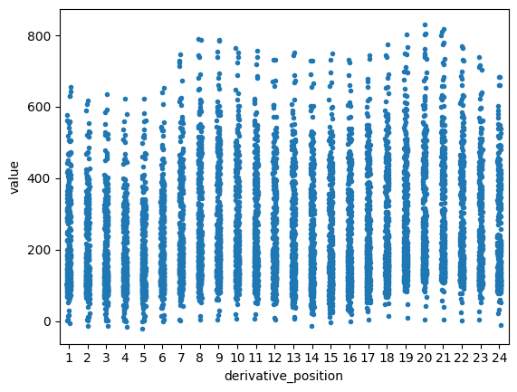

```python
prices = df["Vienna"].query("curve_code == 'CN2IU'")
sns.stripplot(data=prices, x="derivative_position", y="value", size=4)
```